# Tugas 67

Alfikri Ihsan

2023-10-02

1. memanggil package

```r
library(ggplot2)
library(tsibble)
library(tseries)
library(MASS)
library(forecast)
library(TSA)
library(TTR)
library(aTSA)
library(graphics)
```

2. memasukkan data

```r
Data <- readxl::read_xlsx("F:/Semester 5/MPDW/Data Harga Cabai Merah.xlsx")
Dataa <- Data$Harga
```

3. plot time series

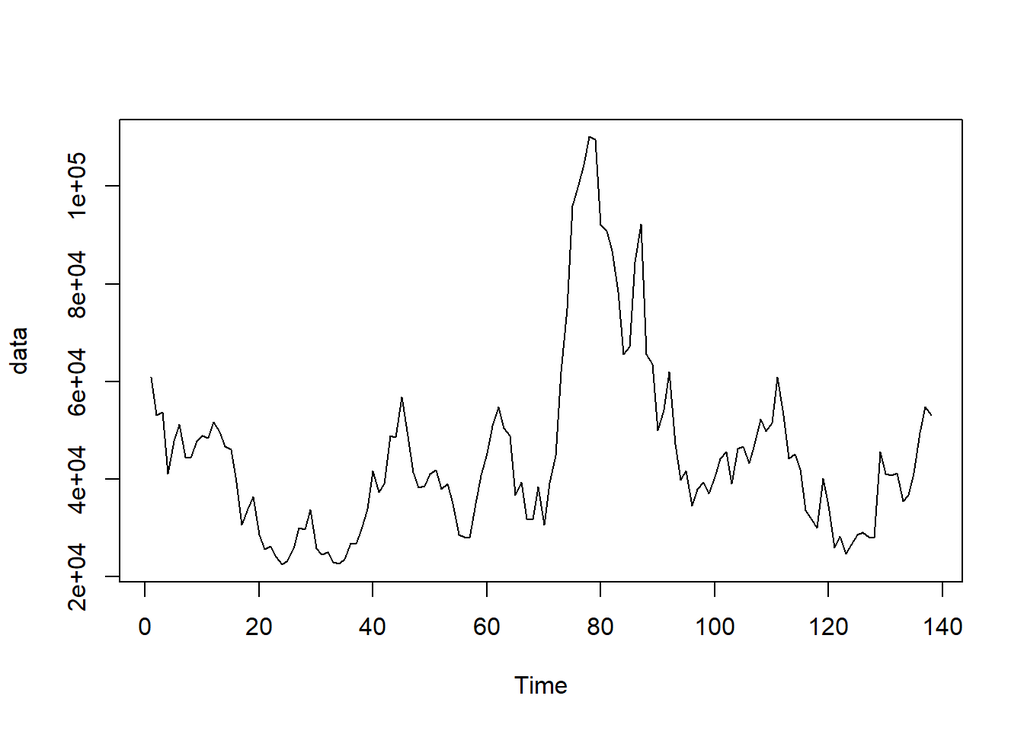

```r
data <- ts(Dataa)
plot.ts(data)
```

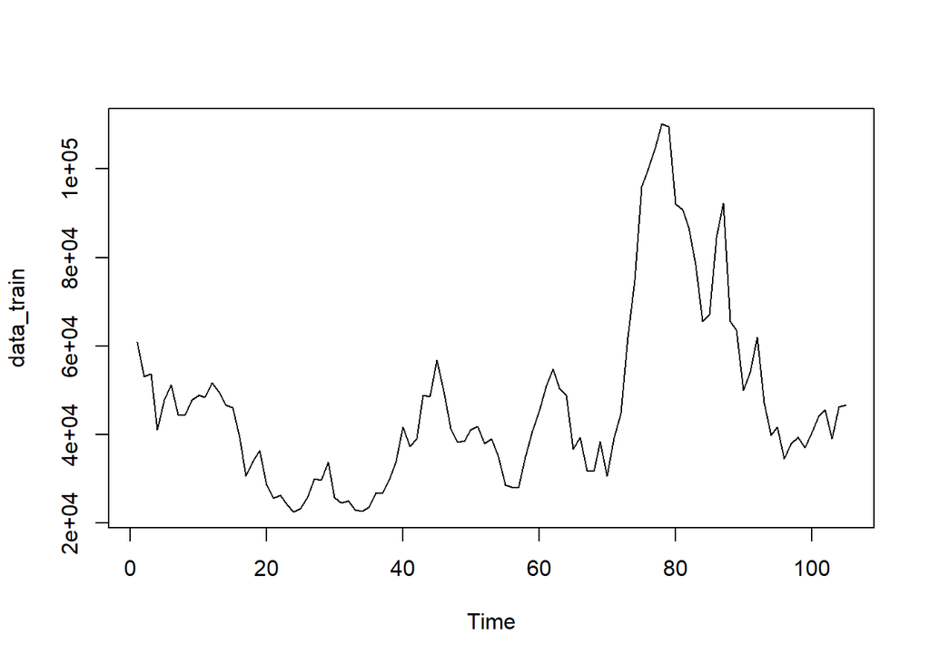

```r
data_train <- data[1:105]
plot.ts(data_train)
```

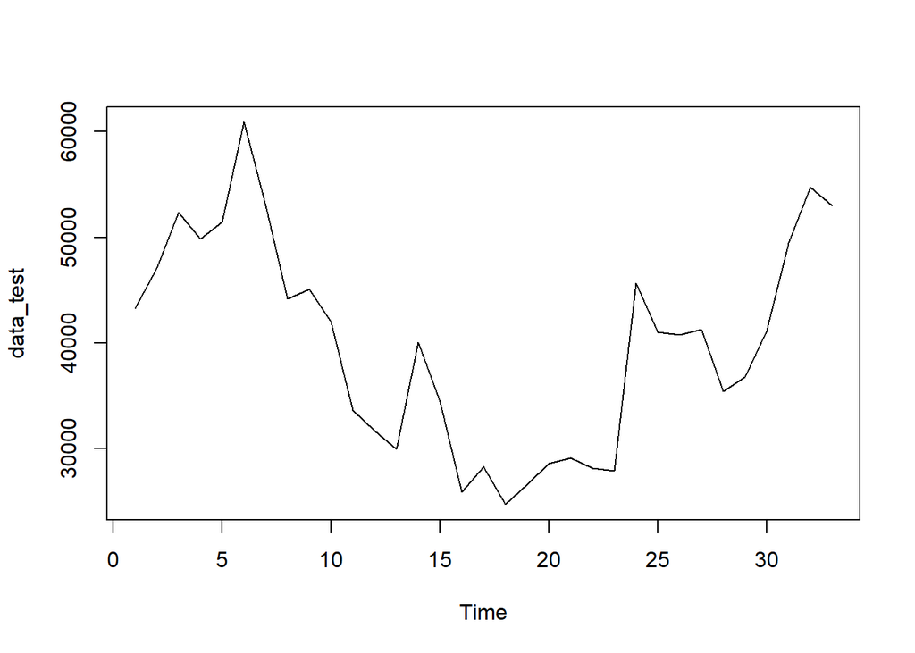

```r
data_test <- data[106:138]
plot.ts(data_test)
```

Data tidak stasioner dalam rataan dan ragam

3. uji plot acf

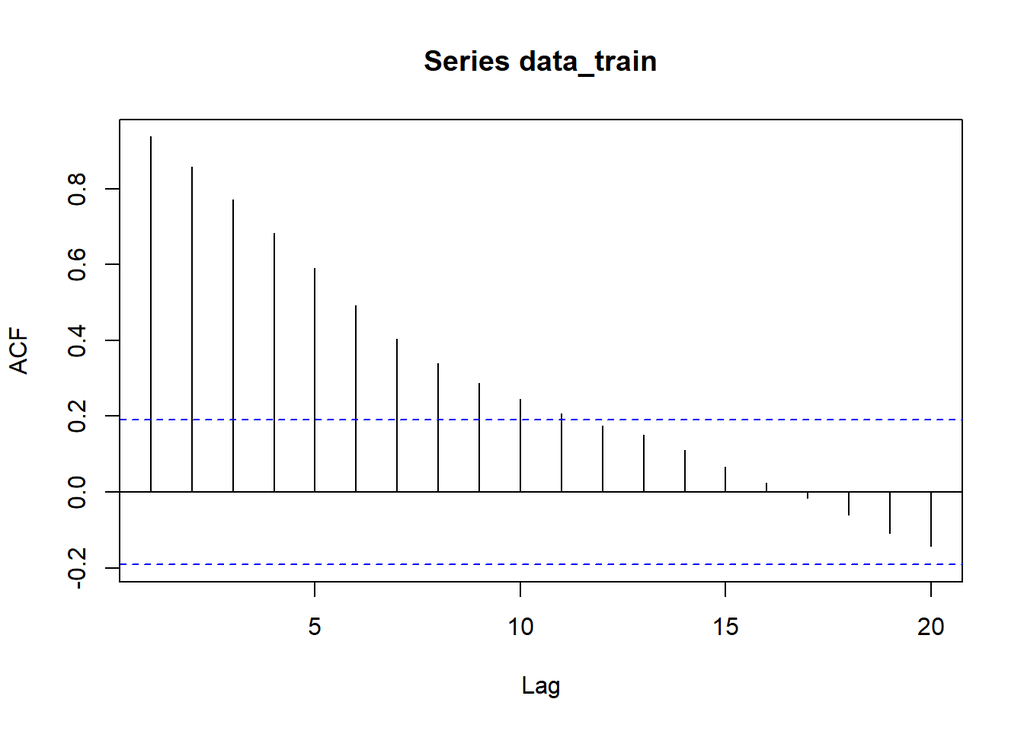

```r
acf(data_train, lag.max = 20)
```

Berdasarkan plot ACF terlihat bahwa data menurun secara Tails off slowly, sehingga dapat disimpulkan data tidak stasioner dalam rataan

4. uji adf

```r
tseries::adf.test(data_train)
```

```
##
##  Augmented Dickey-Fuller Test
##
## data:  data_train
## Dickey-Fuller = -2.701, Lag order = 4, p-value = 0.286
## alternative hypothesis: stationary
```

$H_0$ : Data tidak stasioner dalam rataan

$H_1$ : Data stasioner dalam rataan Berdasarkan uji ADF tersebut, didapat *p-value* sebesar 0.286 yang lebih besar dari taraf nyata 5% dan menandakan bahwa data tidak stasioner dalam rataan. Hal ini sesuai dengan hasil eksplorasi menggunakan plot time series dan plot ACF

5. uji box cox

```r
index <- seq(1:105)
bc = boxcox(data_train~index, lambda = seq(-2,1,by=0.001))
```

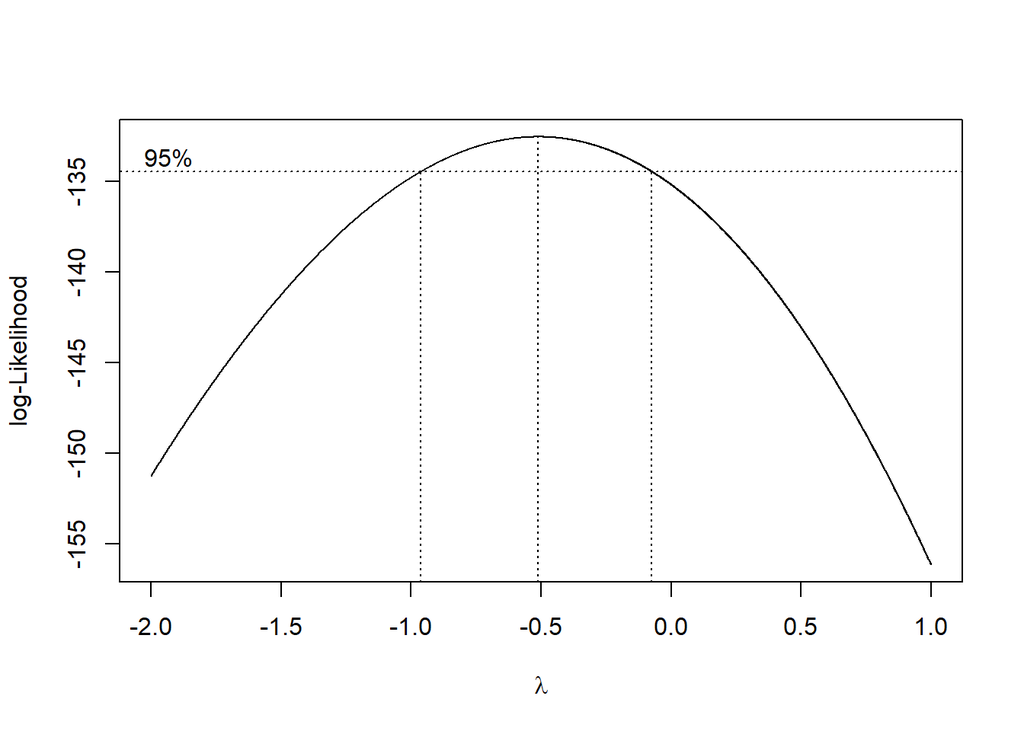

```r
#Nilai Rounded Lambda
lambda <- bc$x[which.max(bc$y)]
lambda
```

```
## [1] -0.511
```

```r
#SK
bc$x[bc$y > max(bc$y) - 1/2 * qchisq(.95,1)]
```

```
##   [1] -0.963 -0.962 -0.961 -0.960 -0.959 -0.958 -0.957 -0.956 -0.955 -0.954
##  [11] -0.953 -0.952 -0.951 -0.950 -0.949 -0.948 -0.947 -0.946 -0.945 -0.944
##  [21] -0.943 -0.942 -0.941 -0.940 -0.939 -0.938 -0.937 -0.936 -0.935 -0.934
##  [31] -0.933 -0.932 -0.931 -0.930 -0.929 -0.928 -0.927 -0.926 -0.925 -0.924
##  [41] -0.923 -0.922 -0.921 -0.920 -0.919 -0.918 -0.917 -0.916 -0.915 -0.914
##  [51] -0.913 -0.912 -0.911 -0.910 -0.909 -0.908 -0.907 -0.906 -0.905 -0.904
##  [61] -0.903 -0.902 -0.901 -0.900 -0.899 -0.898 -0.897 -0.896 -0.895 -0.894
##  [71] -0.893 -0.892 -0.891 -0.890 -0.889 -0.888 -0.887 -0.886 -0.885 -0.884
##  [81] -0.883 -0.882 -0.881 -0.880 -0.879 -0.878 -0.877 -0.876 -0.875 -0.874
##  [91] -0.873 -0.872 -0.871 -0.870 -0.869 -0.868 -0.867 -0.866 -0.865 -0.864
## [101] -0.863 -0.862 -0.861 -0.860 -0.859 -0.858 -0.857 -0.856 -0.855 -0.854
## [111] -0.853 -0.852 -0.851 -0.850 -0.849 -0.848 -0.847 -0.846 -0.845 -0.844
## [121] -0.843 -0.842 -0.841 -0.840 -0.839 -0.838 -0.837 -0.836 -0.835 -0.834
## [131] -0.833 -0.832 -0.831 -0.830 -0.829 -0.828 -0.827 -0.826 -0.825 -0.824
## [141] -0.823 -0.822 -0.821 -0.820 -0.819 -0.818 -0.817 -0.816 -0.815 -0.814
```

[output cut: 74 more lines]

dari plot box cox dalam selang kepercayaan 95% terlihat tidak mengandung lambda = 1, sehingga dapat disimpulkan bahwa data tidak stasioner dalam ragam

6. penanganan ketidakstasioneran data

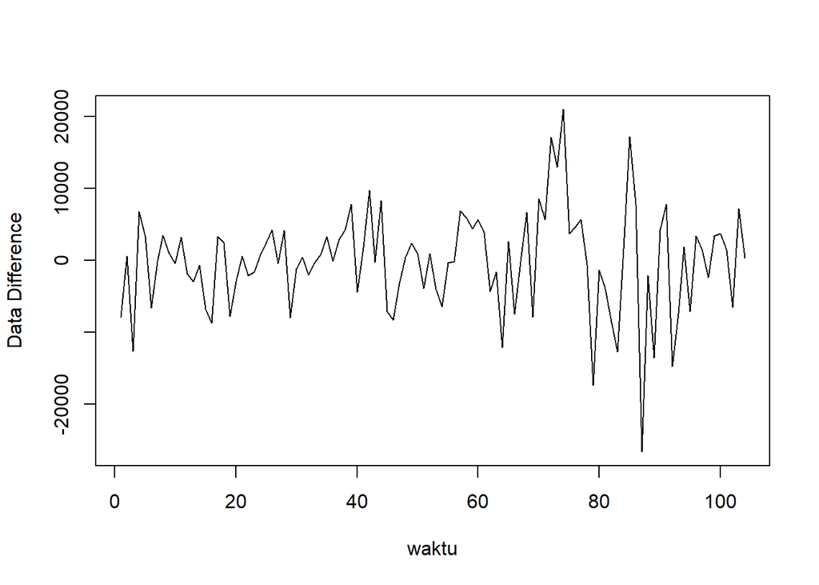

```r
data_train.diff<-diff(data_train,differences = 1)
plot.ts(data_train.diff, lty=1, xlab="waktu", ylab="Data Difference")
```

dilakukan differencing sebanyak 1 kali sehingga diperoleh data yang stasioner dalam rataan

plot acf

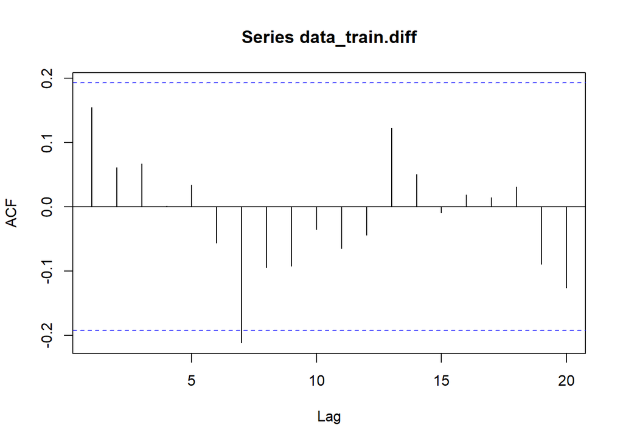

```r
acf(data_train.diff)
```

uji adf

```r
tseries::adf.test(data_train.diff)
```

```
##
##  Augmented Dickey-Fuller Test
##
## data:  data_train.diff
## Dickey-Fuller = -3.8356, Lag order = 4, p-value = 0.01985
## alternative hypothesis: stationary
```

dari uji adf diperoleh p value sebsar 0.01985 dari hasil differencing sebanyak 1 kali, yang artinya data tersebut sudah stasioner dalam rataan

uji eacf

```r
eacf(data_train.diff)
```

```
## AR/MA
##   0 1 2 3 4 5 6 7 8 9 10 11 12 13
## 0 o o o o o o x o o o o  o  o  o
## 1 x o o o o o o o o o o  o  o  o
## 2 x x o o o o o o o o o  o  o  o
## 3 x x o o o o o o o o o  o  o  o
## 4 x o o o o o o o o o o  o  o  o
## 5 x o o x o o o o o o o  o  o  o
## 6 x o o x o x o o o o o  o  o  o
## 7 o x o o o x o o o o o  o  o  o
```

sehingga setelah melihat pola segitiga dapat diperoleh model ARIMA(1,1,1), ARIMA (2,1,2) ARIMA(3,1,2)

### Pendugaan Parameter Model Tentatif

##Model ARIMA (3,1,2)

```r
model1.da=Arima(data_train.diff, order=c(3,1,2),method="ML")
summary(model1.da) #AIC=2130.48
```

```
## Series: data_train.diff
## ARIMA(3,1,2)
##
## Coefficients:
##           ar1     ar2     ar3      ma1      ma2
##       -0.2038  0.0947  0.0863  -0.6360  -0.3640
## s.e.   0.8021  0.1648  0.1025   0.8007   0.8002
##
## sigma^2 = 50604225:  log likelihood = -1059.24
## AIC=2130.48   AICc=2131.35   BIC=2146.29
##
## Training set error measures:
##                    ME     RMSE      MAE      MPE   MAPE      MASE         ACF1
## Training set 572.8289 6905.415 5075.644 78.00043 157.55 0.7380409 -0.008356562
```

```r
lmtest::coeftest(model1.da)
```

```
##
## z test of coefficients:
##
##     Estimate Std. Error z value Pr(>|z|)
## ar1 -0.20383    0.80213 -0.2541   0.7994
## ar2  0.09466    0.16478  0.5745   0.5657
## ar3  0.08630    0.10255  0.8416   0.4000
## ma1 -0.63596    0.80073 -0.7942   0.4271
## ma2 -0.36403    0.80022 -0.4549   0.6492
```

##Model ARIMA (2,1,2)

```r
model2.da=Arima(data_train.diff, order=c(2,1,2),method="ML")
summary(model2.da) #AIC=2128.8
```

```
## Series: data_train.diff
## ARIMA(2,1,2)
##
## Coefficients:
##          ar1      ar2      ma1     ma2
##       0.5595  -0.0069  -1.4030  0.4030
## s.e.  0.6031   0.1526   0.5941  0.5934
##
## sigma^2 = 50257745:  log likelihood = -1059.4
## AIC=2128.8   AICc=2129.42   BIC=2141.98
##
## Training set error measures:
##                    ME     RMSE      MAE      MPE    MAPE      MASE         ACF1
## Training set 561.8999 6916.756 5125.512 80.12195 162.324 0.7452922 -0.007429941
```

```r
lmtest::coeftest(model2.da)
```

```
##
## z test of coefficients:
##
##       Estimate Std. Error z value Pr(>|z|)
## ar1  0.5595291  0.6031335  0.9277  0.35356
## ar2 -0.0068746  0.1525553 -0.0451  0.96406
## ma1 -1.4029747  0.5940676 -2.3616  0.01819 *
## ma2  0.4029770  0.5933957  0.6791  0.49707
## ---
## Signif. codes:  0 '***' 0.001 '**' 0.01 '*' 0.05 '.' 0.1 ' ' 1
```

##Model ARIMA (1,1,1)

```r
model3.da=Arima(data_train.diff, order=c(1,1,1),method="ML")
summary(model3.da) #AIC=2125.24
```

```
## Series: data_train.diff
## ARIMA(1,1,1)
##
## Coefficients:
##          ar1      ma1
##       0.1659  -1.0000
## s.e.  0.0981   0.0324
##
## sigma^2 = 49377766:  log likelihood = -1059.62
## AIC=2125.24   AICc=2125.48   BIC=2133.15
##
## Training set error measures:
##                    ME    RMSE      MAE      MPE     MAPE      MASE        ACF1
## Training set 585.4773 6924.84 5133.909 73.04984 160.6309 0.7465132 -0.01535142
```

```r
lmtest::coeftest(model3.da)
```

```
##
## z test of coefficients:
##
##      Estimate Std. Error  z value Pr(>|z|)
## ar1  0.165930   0.098072   1.6919  0.09066 .
## ma1 -0.999999   0.032364 -30.8986  < 2e-16 ***
## ---
## Signif. codes:  0 '***' 0.001 '**' 0.01 '*' 0.05 '.' 0.1 ' ' 1
```

Dari ketiga model tersebut diperoleh model terbaik yaitu ARIMA (1,1,1) dengan AIC terkecil

#### Eksplorasi Sisaan

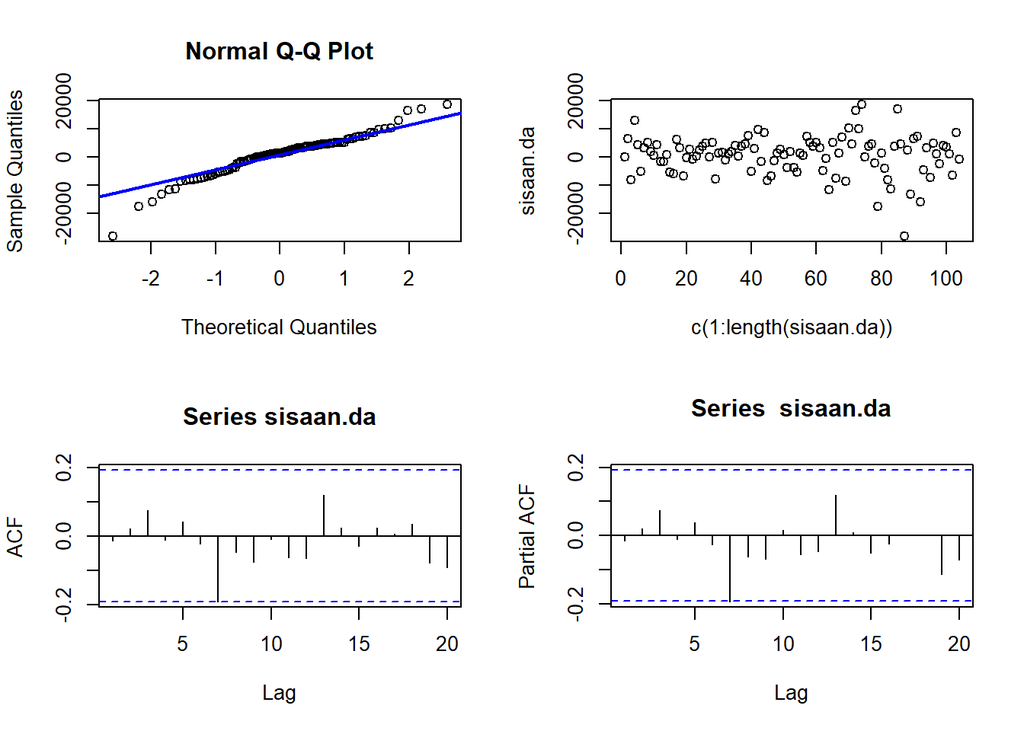

```r
#Eksplorasi
sisaan.da <- model3.da$residuals
par(mfrow=c(2,2))
qqnorm(sisaan.da)
qqline(sisaan.da, col = "blue", lwd = 2)
plot(c(1:length(sisaan.da)),sisaan.da)
acf(sisaan.da)
pacf(sisaan.da)
```

```r
par(mfrow = c(1,1))
```

#### Uji Formal

```r
#1) Sisaan Menyebar Normal
ks.test(sisaan.da,"pnorm")  #tak tolak H0 > sisaan menyebar normal
```

```
##
##  Asymptotic one-sample Kolmogorov-Smirnov test
##
## data:  sisaan.da
## D = 0.61538, p-value < 2.2e-16
## alternative hypothesis: two-sided
```

Selain dengan eksplorasi, asumsi tersebut dapat diuji menggunakan uji formal. Pada tahapan ini uji formal yang digunakan untuk normalitas adalah uji Kolmogorov-Smirnov (KS). Hipotesis pada uji KS adalah sebagai berikut.

$H_0$ : Sisaan menyebar normal

$H_1$ : Sisaan tidak menyebar normal

Berdasarkan uji KS tersebut, didapat *p-value* sebesar 0.00 yang kurang dari taraf nyata 5% sehingga tolak $H_0$ dan menandakan bahwa sisaan tidak menyebar normal. Hal ini sesuai dengan hasil eksplorasi menggunakan plot kuantil-kuantil normal.

```r
#2) Sisaan saling bebas/tidak ada autokorelasi
Box.test(sisaan.da, type = "Ljung")  #tak tolak H0 > sisaan saling bebas
```

```
##
##  Box-Ljung test
##
## data:  sisaan.da
## X-squared = 0.025223, df = 1, p-value = 0.8738
```

Selanjutnya akan dilakukan uji formal untuk kebebasan sisaan menggunakan uji Ljung-Box. Hipotesis yang digunakan adalah sebagai berikut.

$H_0$ : Sisaan saling bebas

$H_1$ : Sisaan tidak tidak saling bebas

```r
#3) Sisaan homogen
Box.test((sisaan.da)^2, type = "Ljung")  #tak tolak H0 > sisaan homogen
```

```
##
##  Box-Ljung test
##
## data:  (sisaan.da)^2
## X-squared = 0.13845, df = 1, p-value = 0.7098
```

Hipotesis yang digunakan untuk uji kehomogenan ragam adalah sebagai berikut.

$H_0$ : Ragam sisaan homogen

$H_1$ : Ragam sisaan tidak homogen

```r
#4) Nilai tengah sisaan sama dengan nol
t.test(sisaan.da, mu = 0, conf.level = 0.95)  #tak tolak h0 > nilai tengah sisaan sama dengan 0
```

```
##
##  One Sample t-test
##
## data:  sisaan.da
## t = 0.86115, df = 103, p-value = 0.3912
## alternative hypothesis: true mean is not equal to 0
## 95 percent confidence interval:
##  -762.9076 1933.8622
## sample estimates:
## mean of x
##  585.4773
```

Terakhir, dengan uji-t, akan dicek apakah nilai tengah sisaan sama dengan nol. Hipotesis yang diujikan sebagai berikut.

$H_0$ : nilai tengah sisaan sama dengan 0

$H_1$ : nilai tengah sisaan tidak sama dengan 0

Berdasarkan uji-ttersebut, didapat *p-value* sebesar 0.3912 yang lebih besar dari taraf nyata 5% sehingga tak tolak $H_0$ dan menandakan bahwa nilai tengah sisaan sama dengan nol. Hal ini berbeda dengan eksplorasi.

### Peramalan

```r
#---FORECAST---#
ramalan.da <- forecast::forecast(model3.da, h = 33)
ramalan.da
```

```
##     Point Forecast     Lo 80    Hi 80     Lo 95    Hi 95
## 105      -68.57157 -9116.970 8979.827 -13906.90 13769.76
## 106     -138.02505 -9324.183 9048.133 -14187.04 13910.99
## 107     -149.54944 -9341.798 9042.700 -14207.88 13908.78
## 108     -151.46168 -9344.264 9041.341 -14210.64 13907.72
## 109     -151.77898 -9344.661 9041.103 -14211.08 13907.52
## 110     -151.83163 -9344.726 9041.063 -14211.15 13907.49
## 111     -151.84036 -9344.737 9041.057 -14211.16 13907.48
## 112     -151.84181 -9344.739 9041.055 -14211.16 13907.48
## 113     -151.84205 -9344.739 9041.055 -14211.17 13907.48
## 114     -151.84209 -9344.739 9041.055 -14211.17 13907.48
## 115     -151.84210 -9344.739 9041.055 -14211.17 13907.48
## 116     -151.84210 -9344.739 9041.055 -14211.17 13907.48
## 117     -151.84210 -9344.739 9041.055 -14211.17 13907.48
## 118     -151.84210 -9344.739 9041.055 -14211.17 13907.48
```

[output cut: 19 more lines]

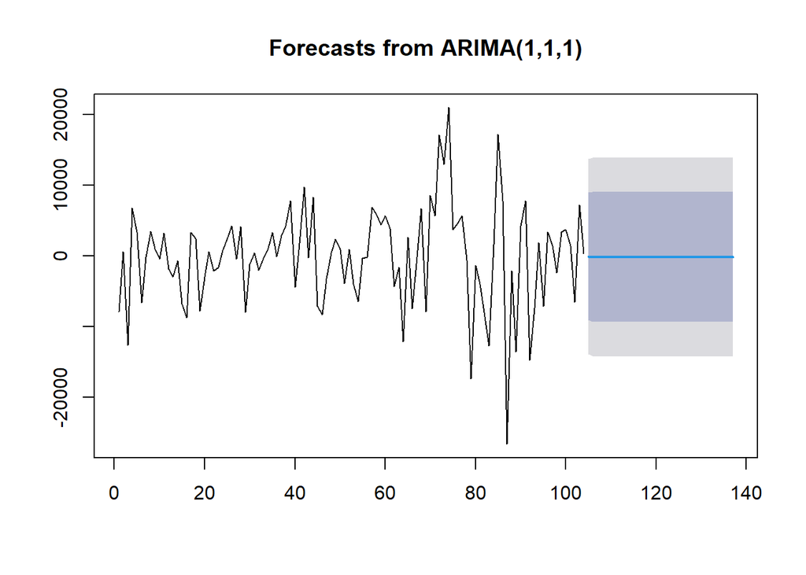

```r
data.ramalan.da <- ramalan.da$mean
plot(ramalan.da)
```

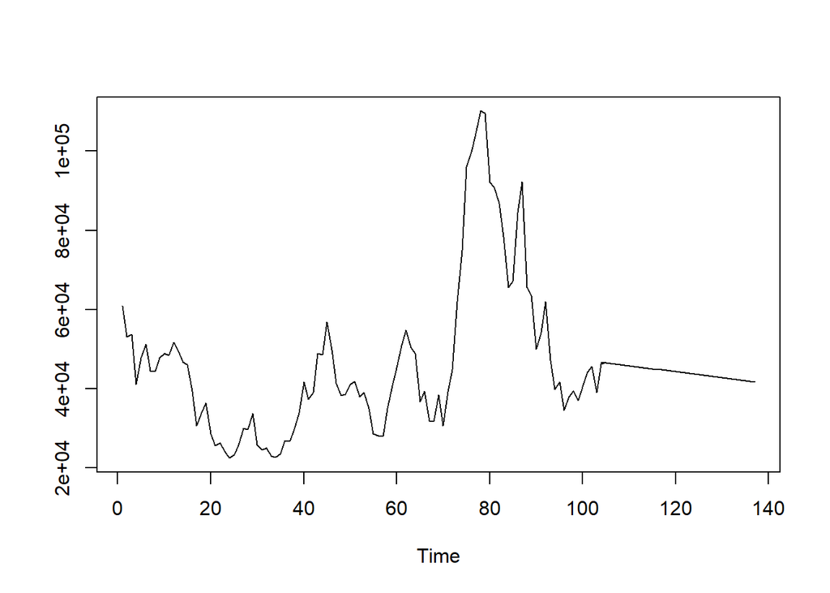

```r
pt_1 <- ts(data_train)[105] #nilai akhir data latih
hasil.forc.Diff <- data.ramalan.da
hasil <- diffinv(hasil.forc.Diff, differences = 1) + pt_1
#has.1 sama hasilnta dengan: cumsum(c(pt_1,hasil.forc.Diff))
ts.plot(ts(data_train),hasil)
```

```r
perbandingan.da<-matrix(data=c(head(ts(data_test), n=33), hasil[-1]),
                     nrow = 33, ncol = 2)
colnames(perbandingan.da)<-c("Aktual","Hasil Forecast")
perbandingan.da
```

```
##       Aktual Hasil Forecast
##  [1,]  43250       46531.43
##  [2,]  47100       46393.40
##  [3,]  52350       46243.85
##  [4,]  49850       46092.39
##  [5,]  51450       45940.61
##  [6,]  60900       45788.78
##  [7,]  53000       45636.94
##  [8,]  44150       45485.10
##  [9,]  45050       45333.26
## [10,]  42000       45181.42
## [11,]  33600       45029.57
## [12,]  31700       44877.73
## [13,]  29900       44725.89
## [14,]  40050       44574.05
```

[output cut: 19 more lines]

```r
accuracy(ts(hasil[-1]), head(ts(data_test), n=33))
```

```
##                 ME     RMSE      MAE       MPE     MAPE      ACF1 Theil's U
## Test set -4205.798 10500.04 8619.478 -17.57317 25.80344 0.7803416  2.019976
```